# Bisphosphonates adverse-events network meta-analysis: event-specific results

2019-10-30

Back to Appendix 2

## LOSS OF APPETITE

[interactive chart not shown]

### Network geometry summary

Proportion of potential comparisons with direct data: 0.15

Proportion of treatments compared to more than one other: 0.33

Median number of studies per direct comparison: 1 (interquartile range 1-1)

Proportion of direct comparisons informed by more than one study: 0.1

## Meta analysis results

Estimates (and 95% credible intervals) of the odds ratio of each bisphosphonate treatment, versus observation only, under

- (green) the best-fitting network meta-analysis model (if feasible)
- (blue) an equivalent meta-analysis of direct comparisons of the same treatment versus an observation-only control, and
- (red) all study-specific direct comparisons odds ratios corresponding to direct comparisons of the treatment with a no-treatment control. Placebo controls (dotted lines) are distinguished from observation-only controls (solid lines).

The panels distinguish the treatment categories under the best-fitting network meta-analysis model.

Note:

- there is one red line for each active study arm in each study containing a placebo or observation-only control. Note that this excludes comparisons of one bisphosphonate against another, which contribute to the network-meta analysis pooled estimates along with the direct comparisons.
- the blue line (direct-data pooled estimate) is the weighted average of all solid red lines (study-specific comparisons against observation-only). If there is no blue line on a particular panel, there were no studies that directly compared that treatment against an observation-only control.
- the green line (network meta-analysis pooled estimate) will not necessarily appear to be the average of the red lines, since the network meta-analysis also includes indirect data from the bisphosphonate-bisphosponate comparisons that are not illustrated
- there is no green line if no network meta-analysis was feasible.

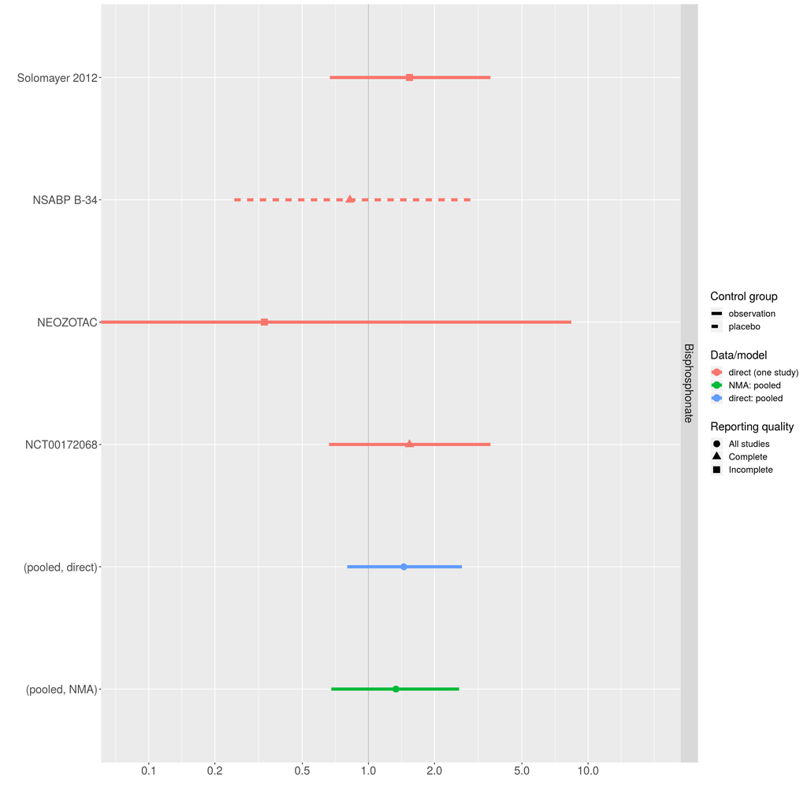

## Comparison of different treatment groupings

Network meta-analysis models defined on different groupings of treatments are compared.

- The treatment groupings compared for this symptom are those for which there is a connected network of trials reporting that symptom.
- Lines indicated pooled estimates of the odds ratio for each treatment against observation only, under the network meta-analysis model on that treatment grouping.
- The statistical fit of the models on different treatment groupings is compared using the deviance information criterion (DIC). DIC are presented relative to the best-fitting model (DIC = 0), and higher DIC indicate worse fit.

For the event LOSS OF APPETITE, observation-only and placebo are considered separately.

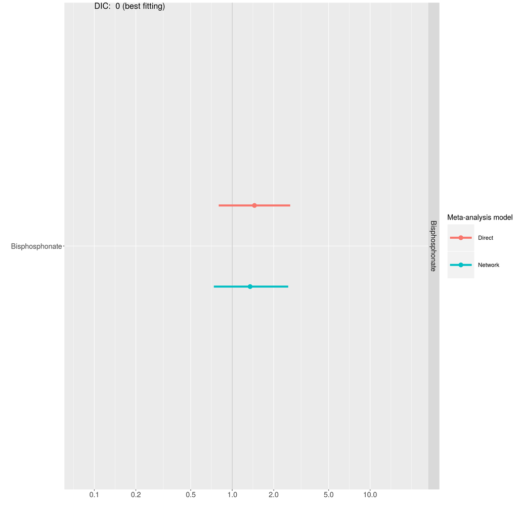